# week7Practice

M. Onimus

10/20/2020

# Read in Data

```r
week7 <- read_sas("practice/logistic_practice_1.sas7bdat") %>%
  mutate(Kyphosis = as.factor(Kyphosis))
```

# Question 1

A 1990 study by Hastie and Tibshirani looked at what factors affect the risk of developing kyphosis (severe forward flexion of the spine) after corrective spinal surgery in infants. The provided data reports whether the infant developed kyphosis and the age (in months) when they had surgery.

## Question/Answer 1a

Provide a box plot of age versus kyphosis. Hint: PROC Boxplot; plot X*Y; run;

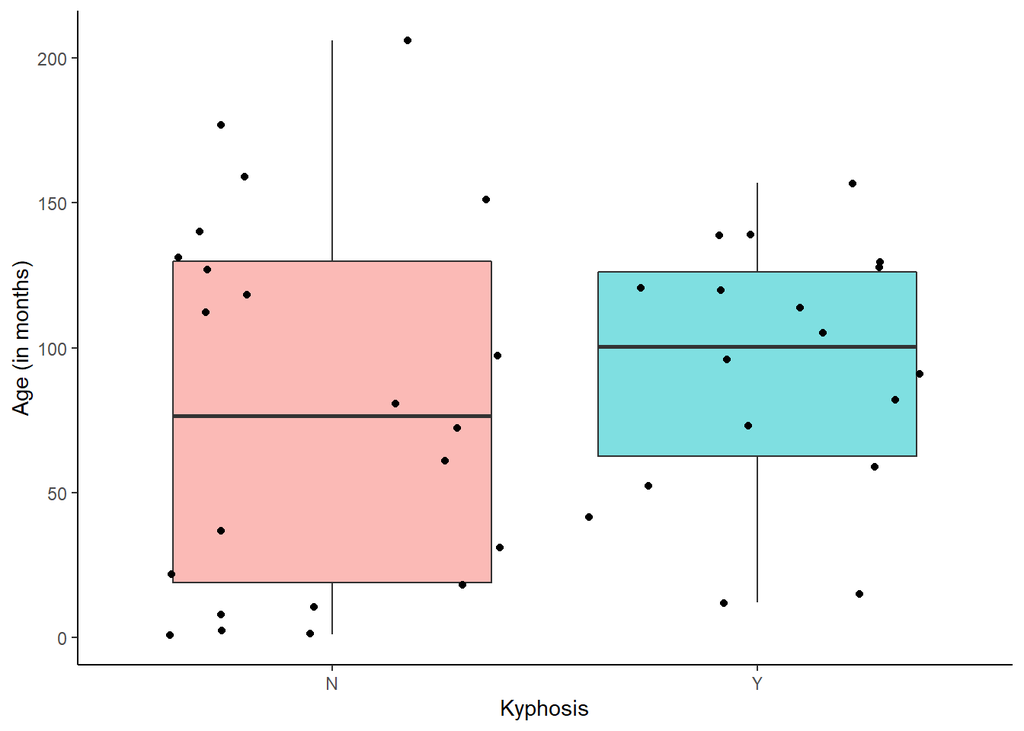

```r
ggplot(week7, aes(x = Kyphosis, y = Age, fill = Kyphosis)) +
  geom_boxplot(alpha = 0.5) +
  geom_jitter() +
  theme_classic() +
  theme(legend.position = 'none') +
  labs(y = 'Age (in months)')
```

## Question/Answer 1b

Qualitatively, do kyphosis cases seem to have been younger or older at the time of surgery than controls?

**Qualitatively, it appears like the risk of develop kryphosis increases as age (in months) increases.**

## Question/Answer 1c

What are the null and alternative hypotheses for testing an association between age and kyphosis, using your logistic regression model?

$H_0:\beta_1 = 0$ $H_A:\beta_1 \neq 0$

## Question/Answer 1d

What is the odds ratio for age, along with its 95% CI?

```r
lm <- glm(Kyphosis ~ Age, family = 'binomial', data = week7)

# find the odds ratio using exp

odds <- exp(coefficients(lm))

# or use another package to pull it out

oddsEPI <- epiDisplay::logistic.display(lm)
```

**The odds ratio point estimate with the 95% CI is 1.0043 (0.9929,1.0159) .**

## Question/Answer 1e

What are the results of inference? Report the test statistic, its distribution, and the associated p-value.

```r
summary(lm)
```

```
##
## Call:
## glm(formula = Kyphosis ~ Age, family = "binomial", data = week7)
##
## Deviance Residuals:
##     Min       1Q   Median       3Q      Max
## -1.3126  -1.0907  -0.9482   1.2170   1.4052
##
## Coefficients:
##              Estimate Std. Error z value Pr(>|z|)
## (Intercept) -0.572693   0.602395  -0.951    0.342
## Age          0.004296   0.005849   0.734    0.463
##
## (Dispersion parameter for binomial family taken to be 1)
##
##     Null deviance: 55.051  on 39  degrees of freedom
## Residual deviance: 54.504  on 38  degrees of freedom
## AIC: 58.504
##
## Number of Fisher Scoring iterations: 4
```

**In SAS, the $\chi^2$ = 0.5393 with an associated p-value of 0.4627.**

**In R, I am provided with a z-value of 0.734 with an associated p-value of 0.463.**

## Question/Answer 1h

Write a brief interpretation of these results.

**Child’s age in the sample was not signifanctly associated with the odds of kyphosis (z-value = 0.734, p-value = 0.463). Additionally, each additional month increased the odds by 0.43% (95% CI: 0.9929, 1.0159).**